# Civiencia Projekt Eco-data

## Análisis estadístico de opiniones españolas sobre ecología y cambio climático.

### Una aproximación basada en el barómetro del CIS *2018*.

##### Projecto para Civiencia S.L. - Pablo de la Asunción Cumbrera Conde

En el siguiente documento, se analizan y visualizan opiniones sobre diversos temas relacionados con ecología y cambio climático basados en los datos recogidos por el CIS (Centro de Investigaciones Sociológicas) en la población española durante Noviembre de 2018.

Los datos han sido extraidos de http://www.cis.es/cis/opencm/ES/2_bancodatos/estudios/listaEstudiosYear.jsp?year=2018 siendo su descarga gratuita y autorizada.

### Visualización de los datos

```python
import pandas as pd
import numpy as np
import matplotlib as plt
```

```python
path = "file:///C:/Users/pablo/OneDrive/Escritorio/UNIVERSIDAD/Civiencia/civiencia%20datos%20Entrevista%20depurada.xlsx"
```

```python
print ("Las primeras cinco filas de nuestra base de datos")
df=pd.read_excel(path)
df.head()
```

```
Las primeras cinco filas de nuestra base de datos
```

|  | CCAA | TAMUNI | CAPITAL | P12 | P12A | P12B | P12C | P12D01 | P12D02 | P12D03 | ... | P14 | P15 | P17 | P19 | P34 EDAD | P35A | P36 | ESTUDIOS | RAMA09 | ESTATUS |
| --- | --- | --- | --- | --- | --- | --- | --- | --- | --- | --- | --- | --- | --- | --- | --- | --- | --- | --- | --- | --- | --- |
| 0 | 16 | 5 | 1 | 2 | 0 | 0 | 0 | 0 | 0 | 0 | ... | 4 | 3 | 1 | 1 | 42 | 7 | 3 | 5 | 2 | 4 |
| 1 | 16 | 5 | 1 | 8 | 1 | 2 | 1 | 1 | 4 | 6 | ... | 4 | 3 | 2 | 2 | 35 | 6 | 1 | 4 | 4 | 5 |
| 2 | 16 | 5 | 1 | 1 | 1 | 1 | 1 | 1 | 3 | 4 | ... | 4 | 3 | 1 | 2 | 41 | 5 | 3 | 5 | 2 | 4 |
| 3 | 16 | 5 | 1 | 1 | 2 | 2 | 1 | 1 | 3 | 11 | ... | 8 | 8 | 2 | 2 | 41 | 7 | 3 | 5 | 4 | 2 |
| 4 | 16 | 5 | 1 | 1 | 1 | 1 | 1 | 4 | 5 | 9 | ... | 4 | 3 | 1 | 2 | 42 | 7 | 3 | 5 | 2 | 4 |

5 rows × 40 columns

```python
print ("Las últimas cinco filas de nuestra base de datos")
df.tail()
```

```
Las últimas cinco filas de nuestra base de datos
```

|  | CCAA | TAMUNI | CAPITAL | P12 | P12A | P12B | P12C | P12D01 | P12D02 | P12D03 | ... | P14 | P15 | P17 | P19 | P34 EDAD | P35A | P36 | ESTUDIOS | RAMA09 | ESTATUS |
| --- | --- | --- | --- | --- | --- | --- | --- | --- | --- | --- | --- | --- | --- | --- | --- | --- | --- | --- | --- | --- | --- |
| 2969 | 19 | 4 | 1 | 1 | 2 | 3 | 9 | 1 | 4 | 9 | ... | 3 | 3 | 1 | 1 | 40 | 6 | 2 | 4 | 4 | 5 |
| 2970 | 19 | 4 | 1 | 1 | 1 | 1 | 9 | 1 | 3 | 7 | ... | 4 | 7 | 1 | 1 | 26 | 11 | 2 | 6 | 3 | 4 |
| 2971 | 19 | 4 | 1 | 2 | 0 | 0 | 0 | 0 | 0 | 0 | ... | 3 | 8 | 2 | 1 | 18 | 6 | 1 | 4 | 4 | 2 |
| 2972 | 19 | 4 | 1 | 1 | 3 | 2 | 1 | 6 | 9 | 99 | ... | 4 | 3 | 2 | 2 | 23 | 6 | 4 | 4 | 4 | 2 |
| 2973 | 19 | 4 | 1 | 2 | 0 | 0 | 0 | 0 | 0 | 0 | ... | 4 | 7 | 1 | 1 | 39 | 5 | 1 | 5 | 4 | 2 |

5 rows × 40 columns

```python
df.describe()
```

|  | CCAA | TAMUNI | CAPITAL | P12 | P12A | P12B | P12C | P12D01 | P12D02 | P12D03 | ... | P14 | P15 | P17 | P19 | P34 EDAD | P35A | P36 | ESTUDIOS | RAMA09 | ESTATUS |
| --- | --- | --- | --- | --- | --- | --- | --- | --- | --- | --- | --- | --- | --- | --- | --- | --- | --- | --- | --- | --- | --- |
| count | 2974.000000 | 2974.00000 | 2974.000000 | 2974.000000 | 2974.000000 | 2974.000000 | 2974.000000 | 2974.000000 | 2974.000000 | 2974.000000 | ... | 2974.000000 | 2974.000000 | 2974.000000 | 2974.000000 | 2974.000000 | 2974.000000 | 2974.000000 | 2974.000000 | 2974.000000 | 2974.000000 |
| mean | 8.256557 | 3.89341 | 2.453598 | 1.568594 | 1.482515 | 1.908877 | 1.458978 | 6.027236 | 9.837592 | 17.729321 | ... | 3.600538 | 5.299933 | 2.148958 | 2.140888 | 50.529254 | 5.858776 | 1.907532 | 3.948554 | 3.452925 | 2.977135 |
| std | 4.731728 | 1.72721 | 0.824510 | 1.759077 | 1.334501 | 2.223344 | 1.970220 | 19.950972 | 22.065512 | 29.336130 | ... | 1.279800 | 2.267545 | 1.661885 | 1.662386 | 17.894982 | 5.294257 | 1.548365 | 1.583969 | 1.214736 | 1.582196 |
| min | 1.000000 | 1.00000 | 1.000000 | 1.000000 | 0.000000 | 0.000000 | 0.000000 | 0.000000 | 0.000000 | 0.000000 | ... | 1.000000 | 1.000000 | 1.000000 | 1.000000 | 18.000000 | 0.000000 | 1.000000 | 1.000000 | 1.000000 | 1.000000 |
| 25% | 4.000000 | 3.00000 | 2.000000 | 1.000000 | 1.000000 | 1.000000 | 1.000000 | 1.000000 | 3.000000 | 5.000000 | ... | 3.000000 | 3.000000 | 1.000000 | 1.000000 | 37.000000 | 4.000000 | 1.000000 | 3.000000 | 3.000000 | 2.000000 |
| 50% | 9.000000 | 4.00000 | 3.000000 | 1.000000 | 1.000000 | 1.000000 | 1.000000 | 1.000000 | 4.000000 | 9.000000 | ... | 3.000000 | 7.000000 | 2.000000 | 2.000000 | 50.000000 | 5.000000 | 1.000000 | 4.000000 | 4.000000 | 3.000000 |
| 75% | 12.000000 | 5.00000 | 3.000000 | 1.000000 | 2.000000 | 2.000000 | 1.000000 | 3.000000 | 7.000000 | 12.000000 | ... | 4.000000 | 7.000000 | 2.000000 | 2.000000 | 64.000000 | 7.000000 | 3.000000 | 5.000000 | 4.000000 | 4.000000 |
| max | 19.000000 | 7.00000 | 3.000000 | 9.000000 | 9.000000 | 9.000000 | 9.000000 | 99.000000 | 99.000000 | 99.000000 | ... | 9.000000 | 9.000000 | 9.000000 | 9.000000 | 98.000000 | 99.000000 | 9.000000 | 9.000000 | 9.000000 | 9.000000 |

8 rows × 27 columns

### Composición de la muestra

- La muestra está compuesta por sujetos provenientes de las diferentes Comunidades autónomas (19).
- El muestro ha sido seleccionado proporcionalmente desde el número de habitantes totales del país por habitantes totales de cada región.
- Error muestral: Para un nivel de confianza del 95,5% (dos sigmas), y P = Q, el error real es de ±1,8% para el conjunto de la muestra y en el supuesto de muestreo aleatorio simple.

```python
bins = np.linspace(min(df["CCAA"]), max(df["CCAA"]), 20)
group_names = ['Andalucía','Aragón','Asturias','Balears','Canarias','Cantabria','Castilla-La Mancha',
               'Castilla y León','Cataluña','Comunitat_Valenciana','Extremadura',
               'Galicia','Madrid','Murcia','Navarra','País Vasco','Rioja','Ceuta','Melilla']
df['CCAA-binned'] = pd.cut(df['CCAA'], bins, labels=group_names, include_lowest=True )
CCAA_counts=df["CCAA-binned"].value_counts().to_frame()
print (CCAA_counts)
```

```
                      CCAA-binned
Andalucía                     543
Cataluña                      455
Madrid                        392
Comunitat_Valenciana          306
Galicia                       196
Castilla y León               171
País Vasco                    148
Canarias                      132
Castilla-La Mancha            131
Murcia                         86
Aragón                         85
Extremadura                    76
Asturias                       75
Balears                        66
Navarra                        41
Cantabria                      40
Rioja                          21
Ceuta                           5
Melilla                         5
```

[figure not shown]

```python
%matplotlib inline
from matplotlib import pyplot
group_names1 = ['An','Cat','Ma','C.V', 'G','CyL','PV','Can','ClM','Mu','Ar','Ex','As','Ba','Nav','Can','Ri','Ce','Me']
pyplot.bar(group_names1,df["CCAA-binned"].value_counts())
plt.pyplot.xlabel("Comunidades autónomas")
plt.pyplot.ylabel("Número de sujetos en la muestra")
plt.pyplot.title("Proporción de procedencia de sujetos muestra")
```

### Opiniones y visualizaciones

- A continuación mostraremos el análisis de los datos y la visualización de éstos.
- Toda cuestión irá encabezada por la formulación así como del etiquetado original.

#### 1. Conocimiento de la existencia de un cambio climático actualmente (P12)

```python
df["P12"].value_counts().sort_index()
```

```
1    2479
2     298
8     183
9      14
Name: P12, dtype: int64
```

[figure not shown]

```python
fig, ax = plt.subplots(figsize=(9, 6), subplot_kw=dict(aspect="equal"))

recipe = ["Sí cree que hay un cambio climático", "No cree que haya un cambio climático", "         Está en duda, no lo sabe","N.C."]

data = [2479, 298, 46, 10]

wedges, texts = ax.pie(data, wedgeprops=dict(width=0.5), startangle=-40)

bbox_props = dict(boxstyle="square,pad=0.3", fc="w", ec="k", lw=0.72)
kw = dict(arrowprops=dict(arrowstyle="-"),
          bbox=bbox_props, zorder=0, va="center")

for i, p in enumerate(wedges):
    ang = (p.theta2 - p.theta1)/2. + p.theta1
    y = np.sin(np.deg2rad(ang))
    x = np.cos(np.deg2rad(ang))
    horizontalalignment = {-1: "right", 1: "left"}[int(np.sign(x))]
    connectionstyle = "angle,angleA=0,angleB={}".format(ang)
    kw["arrowprops"].update({"connectionstyle": connectionstyle})
    ax.annotate(recipe[i], xy=(x, y), xytext=(1.35*np.sign(x), 1.2*y),
                horizontalalignment=horizontalalignment, **kw)

ax.set_title("                     1.Conocimiento de la existencia de un cambio climático actualmente")

plt.show()
```

#### 2. Grado de la influencia en el cambio climático de la acciónde los seres humanos, la industria, coches, gases, etc. (12A)

```python
df["P12A"].value_counts().sort_index()
```

```
0     312
1    1547
2     940
3      53
4      39
5       5
8      60
9      18
Name: P12A, dtype: int64
```

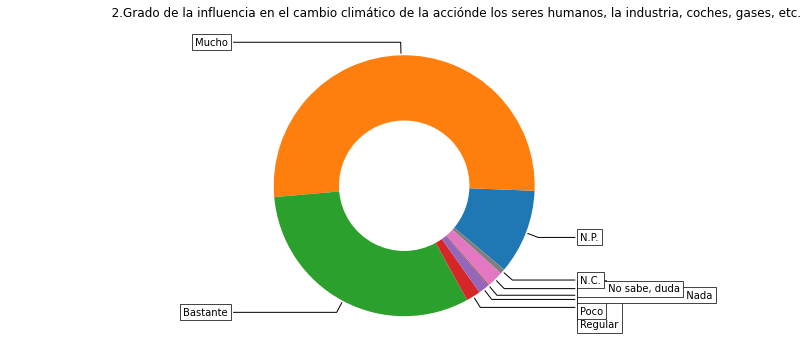

```python
fig, ax = plt.subplots(figsize=(9, 6), subplot_kw=dict(aspect="equal"))

recipe = ["N.P.","Mucho","Bastante", "          \n \n   \nRegular","\n\nPoco","                                  Nada","         No sabe, duda", "N.C."]

data = [312, 1547, 940, 53, 39, 5, 60, 18]

wedges, texts = ax.pie(data, wedgeprops=dict(width=0.5), startangle=-40)

bbox_props = dict(boxstyle="square,pad=0.3", fc="w", ec="k", lw=0.72)
kw = dict(arrowprops=dict(arrowstyle="-"),
          bbox=bbox_props, zorder=0, va="center")

for i, p in enumerate(wedges):
    ang = (p.theta2 - p.theta1)/2. + p.theta1
    y = np.sin(np.deg2rad(ang))
    x = np.cos(np.deg2rad(ang))
    horizontalalignment = {-1: "right", 1: "left"}[int(np.sign(x))]
    connectionstyle = "angle,angleA=0,angleB={}".format(ang)
    kw["arrowprops"].update({"connectionstyle": connectionstyle})
    ax.annotate(recipe[i], xy=(x, y), xytext=(1.35*np.sign(x), 1.1*y),
                horizontalalignment=horizontalalignment, **kw)

ax.set_title("                           2.Grado de la influencia en el cambio climático de la acciónde los seres humanos, la industria, coches, gases, etc.")

plt.show()
```

#### 3. Opinión sobre si se puede parar y dar marcha atrás o nose puede hacer nada respecto al cambio climático (12b)

```python
df["P12B"].value_counts().sort_index()
```

```
0     312
1    1670
2     559
3     123
8     270
9      40
Name: P12B, dtype: int64
```

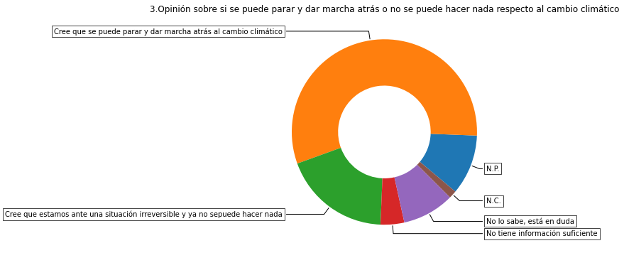

```python
fig, ax = plt.subplots(figsize=(9, 6), subplot_kw=dict(aspect="equal"))

recipe = ["N.P.","Cree que se puede parar y dar marcha atrás al cambio climático",
        "Cree que estamos ante una situación irreversible y ya no sepuede hacer nada","No tiene información suficiente",
          "No lo sabe, está en duda","N.C."]

data = [312, 1670, 559, 123, 270, 40]

wedges, texts = ax.pie(data, wedgeprops=dict(width=0.5), startangle=-40)

bbox_props = dict(boxstyle="square,pad=0.3", fc="w", ec="k", lw=0.72)
kw = dict(arrowprops=dict(arrowstyle="-"),
          bbox=bbox_props, zorder=0, va="center")

for i, p in enumerate(wedges):
    ang = (p.theta2 - p.theta1)/2. + p.theta1
    y = np.sin(np.deg2rad(ang))
    x = np.cos(np.deg2rad(ang))
    horizontalalignment = {-1: "right", 1: "left"}[int(np.sign(x))]
    connectionstyle = "angle,angleA=0,angleB={}".format(ang)
    kw["arrowprops"].update({"connectionstyle": connectionstyle})
    ax.annotate(recipe[i], xy=(x, y), xytext=(1.1*np.sign(x), 1.1*y),
                horizontalalignment=horizontalalignment, **kw)

ax.set_title("3.Opinión sobre si se puede parar y dar marcha atrás o no se puede hacer nada respecto al cambio climático")

plt.show()
```

#### 4. Posicionamiento ante si el cambio climático obliga a uncambio en el funcionamiento de nuestras sociedades (12c)

```python
df["P12C"].value_counts().sort_index()
```

```
0     312
1    2342
2     110
8     113
9      97
Name: P12C, dtype: int64
```

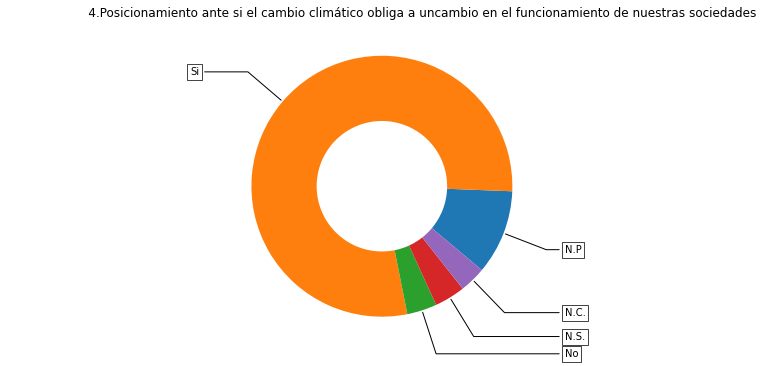

```python
fig, ax = plt.subplots(figsize=(9, 6), subplot_kw=dict(aspect="equal"))

recipe = ["N.P", "Si", "No", "N.S.","N.C."]

data = [312, 2342, 110, 113, 97]

wedges, texts = ax.pie(data, wedgeprops=dict(width=0.5), startangle=-40)

bbox_props = dict(boxstyle="square,pad=0.3", fc="w", ec="k", lw=0.72)
kw = dict(arrowprops=dict(arrowstyle="-"),
          bbox=bbox_props, zorder=0, va="center")

for i, p in enumerate(wedges):
    ang = (p.theta2 - p.theta1)/2. + p.theta1
    y = np.sin(np.deg2rad(ang))
    x = np.cos(np.deg2rad(ang))
    horizontalalignment = {-1: "right", 1: "left"}[int(np.sign(x))]
    connectionstyle = "angle,angleA=0,angleB={}".format(ang)
    kw["arrowprops"].update({"connectionstyle": connectionstyle})
    ax.annotate(recipe[i], xy=(x, y), xytext=(1.4*np.sign(x), 1.35*y),
                horizontalalignment=horizontalalignment, **kw)

ax.set_title("                     4.Posicionamiento ante si el cambio climático obliga a uncambio en el funcionamiento de nuestras sociedades")

plt.show()
```

#### 5. Cambios que se deberían fomentar para atajar el cambio climático (3) (MR) (12d)

```python
df[['P12D01', 'P12D02','P12D03']].apply(pd.Series.value_counts)
```

|  | P12D01 | P12D02 | P12D03 |
| --- | --- | --- | --- |
| 0 | 422.0 | 422.0 | 422.0 |
| 1 | 1581.0 | NaN | NaN |
| 2 | 175.0 | 289.0 | NaN |
| 3 | 151.0 | 349.0 | 93.0 |
| 4 | 305.0 | 588.0 | 191.0 |
| 5 | 66.0 | 285.0 | 131.0 |
| 6 | 63.0 | 285.0 | 203.0 |
| 7 | 15.0 | 70.0 | 76.0 |
| 8 | 19.0 | 109.0 | 131.0 |
| 9 | 20.0 | 143.0 | 339.0 |
| 10 | 23.0 | 173.0 | 327.0 |
| 11 | 2.0 | 55.0 | 257.0 |
| 12 | 1.0 | 36.0 | 431.0 |
| 13 | NaN | NaN | 27.0 |
| 16 | NaN | 1.0 | 8.0 |
| 96 | 3.0 | 6.0 | 10.0 |
| 98 | 48.0 | NaN | NaN |
| 99 | 80.0 | 163.0 | 328.0 |

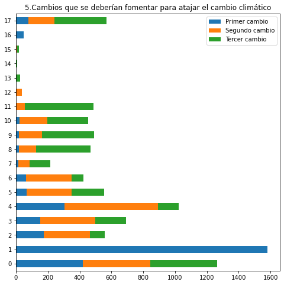

```python
a = [422,1581,175,151,305,66,63,15,19,20,23,2,1,0,0,3,48,80]
b = [422,0,289,349,588,285,285,70,109,143,173,55,36,0,1,6,0,163]
c = [422,0,93,191,131,203,76,131,339,327,257,431,0,27,8,10,0,328]
df = pd.DataFrame({'Primer cambio' : a,'Segundo cambio' : b, 'Tercer cambio' : c})
ax = df.plot.barh(stacked=True);

ax.figure.set_size_inches(8,8)

ax.set_title("5.Cambios que se deberían fomentar para atajar el cambio climático")
ax.legend(loc='upper right')
```

##### Leyenda

###### 17. N.C.

###### 16. N.S.

###### 15. Otra/s

###### 14. Eliminar el plástico en el consumo y venta de productos

###### 13. Promover el completo etiquetado de los productos

###### 12. Cuidar los bosques

###### 11. Fomentar el transporte público eléctrico, las bicicletas o los coches compartidos

###### 10.Proteger el agua de los ríos, lagos, mares

###### 9. Tener una cultura más ecológica

###### 8. Reducir el uso de pesticidas agrícolas

###### 7. Comprar productos que utilicen materiales ecológicos

###### 6. Gestionar adecuadamente un mayor número de residuos

###### 5. Poner impuestos ecológicos a las industrias contaminantes

###### 4. Usar energías renovable

###### 3. Sustituir los coches que usan gasolina o gasoil por vehículos eléctricos o híbridos

###### 2. Cambiar las calefacciones que usan combustibles fósiles por otras de energías renovables

###### 1. Reducir las emisiones de gases contaminantes de las industrias

###### 0. N.P.

#### 6. Cambios a nivel individual que habría que incorporar debido al cambio climático (12e)

```python
df[['P12E01', 'P12E02','P12E03','P12E04','P12E05','P12E06','P12E07','P12E08', 'P12E09','P12E10','P12E11','P12E12','P12E13']].apply(pd.Series.value_counts)
```

|  | P12E01 | P12E02 | P12E03 | P12E04 | P12E05 | P12E06 | P12E07 | P12E08 | P12E09 | P12E10 | P12E11 | P12E12 | P12E13 |
| --- | --- | --- | --- | --- | --- | --- | --- | --- | --- | --- | --- | --- | --- |
|  | 1762.0 | 1142.0 | 1584.0 | 754.0 | 1758.0 | 1082.0 | 1190.0 | 1635.0 | 1716.0 | 1747.0 | 2534.0 | 2492.0 | 2532.0 |
| 1 | 790.0 | 1410.0 | 968.0 | 1798.0 | 794.0 | 1470.0 | 1362.0 | 917.0 | 836.0 | 805.0 | 18.0 | NaN | NaN |
| 0 | 422.0 | 422.0 | 422.0 | 422.0 | 422.0 | 422.0 | 422.0 | 422.0 | 422.0 | 422.0 | 422.0 | 422.0 | 422.0 |
| 8 | NaN | NaN | NaN | NaN | NaN | NaN | NaN | NaN | NaN | NaN | NaN | 60.0 | NaN |
| 9 | NaN | NaN | NaN | NaN | NaN | NaN | NaN | NaN | NaN | NaN | NaN | NaN | 20.0 |

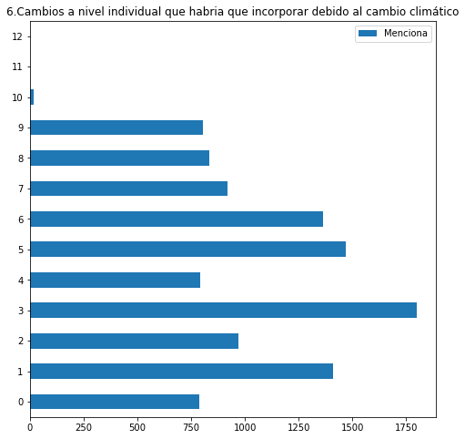

```python
a = [790, 1410,968, 1798,794, 1470,1362, 917,836, 805,18, 0,0]
df = pd.DataFrame({'Menciona' : a,})
ax = df.plot.barh(stacked=True);

ax.figure.set_size_inches(8,8)

ax.set_title("6.Cambios a nivel individual que habria que incorporar debido al cambio climático")
ax.legend(loc='upper right')
```

##### Leyenda

###### 10. Otra/as ¿Cuáles?

###### 9.Consumir, en general, menos productos.

###### 8.Usar vehículos eléctricos o híbridos.

###### 7.Instalar placas solares en su vivienda.

###### 6.Controlar el consumo de agua.

###### 5.Controlar el consumo de energía en la vivienda.

###### 4.Comprar productos de proximidad y de temporada.

###### 3.Reciclar productos: cristal, papel, aceites, plásticos.

###### 2.Reutilizar en mayor grado objetos.

###### 1.Utilizar transportes alternativos: bicicletas, transportes públicos ecológicos, etc.

###### 0. Consumir productos ecológicos.

#### 7. Frases sobre supuestos del cambio climático (13)

```python
df[['P1301', 'P1302','P1303','P1304','P1305','P1306','P1307']].apply(pd.Series.value_counts)
```

|  | P1301 | P1302 | P1303 | P1304 | P1305 | P1306 | P1307 |
| --- | --- | --- | --- | --- | --- | --- | --- |
| 1 | 192 | 144 | 154 | 1383 | 98 | 980 | 914 |
| 2 | 748 | 436 | 624 | 1131 | 391 | 1446 | 1164 |
| 3 | 1051 | 902 | 722 | 208 | 986 | 281 | 225 |
| 4 | 899 | 1283 | 911 | 118 | 1124 | 72 | 102 |
| 8 | 78 | 202 | 551 | 110 | 361 | 190 | 552 |
| 9 | 6 | 7 | 12 | 24 | 14 | 5 | 17 |

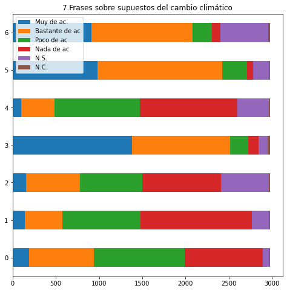

```python
a = [192,144,154,1383,98,980,914]
b = [748,436,624,1131,391,1446,1164]
c = [1051,902,722,208,986,281,225]
d = [899,1283,911,118,1124,72,102]
e = [78,202,551,110,361,190,552]
f = [6,7,12,24,14,5,17]
df = pd.DataFrame({'Muy de ac.' : a,'Bastante de ac' : b, 'Poco de ac' : c, 'Nada de ac' : d, 'N.S.' : e, 'N.C.' : f})
ax = df.plot.barh(stacked=True);

ax.figure.set_size_inches(8,8)

ax.set_title("7.Frases sobre supuestos del cambio climático")
ax.legend(loc='upper left')
```

##### Leyenda

###### 6. El negacionismo sobre el cambioclimático ha estado promovido por las grandes industrias que causan mayor deterioro ecológico.

###### 5.Cambiar nuestras formas de vida, ayudaría a resolver el problema del cambio climático.

###### 4.La ciencia y la tecnología por sí solas resolverán el problema del cambio climático.

###### 3.El que contamina debería pagar por contaminar.

###### 2.Los que nos asustan sobre el cambio climático están al servicio de las compañías ecologistas.

###### 1.Se exagera mucho al hablar del peligro que supone el cambio climático.

###### 0.Es muy difícil que una persona como yo pueda hacer algo para luchar contra el cambio climático.

```python
df["P14"].value_counts().sort_index()
```

```
1      17
2     157
3    1563
4    1054
8     175
9       8
Name: P14, dtype: int64
```

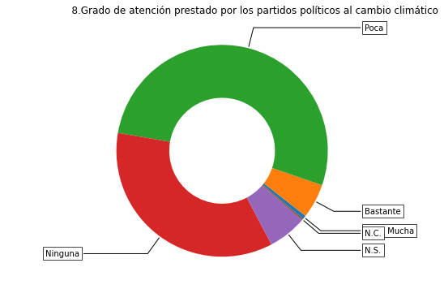

```python
fig, ax = plt.subplots(figsize=(9, 6), subplot_kw=dict(aspect="equal"))

recipe = ["         Mucha", "Bastante", "Poca", "Ninguna","N.S.","N.C."]

data = [17, 157, 1563, 1054, 175, 8]

wedges, texts = ax.pie(data, wedgeprops=dict(width=0.5), startangle=-40)

bbox_props = dict(boxstyle="square,pad=0.3", fc="w", ec="k", lw=0.72)
kw = dict(arrowprops=dict(arrowstyle="-"),
          bbox=bbox_props, zorder=0, va="center")

for i, p in enumerate(wedges):
    ang = (p.theta2 - p.theta1)/2. + p.theta1
    y = np.sin(np.deg2rad(ang))
    x = np.cos(np.deg2rad(ang))
    horizontalalignment = {-1: "right", 1: "left"}[int(np.sign(x))]
    connectionstyle = "angle,angleA=0,angleB={}".format(ang)
    kw["arrowprops"].update({"connectionstyle": connectionstyle})
    ax.annotate(recipe[i], xy=(x, y), xytext=(1.35*np.sign(x), 1.2*y),
                horizontalalignment=horizontalalignment, **kw)

ax.set_title("                     8.Grado de atención prestado por los partidos políticos al cambio climático")

plt.show()
```

```python
df["P17"].value_counts().sort_index()
```

```
1    1096
2    1325
3     284
4      94
8     158
9      17
Name: P17, dtype: int64
```

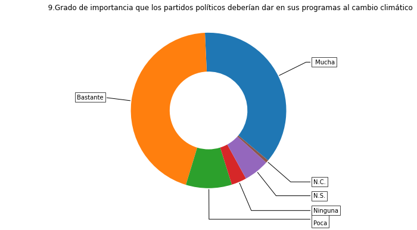

```python
fig, ax = plt.subplots(figsize=(9, 6), subplot_kw=dict(aspect="equal"))

recipe = [" Mucha", "Bastante", "\nPoca", "Ninguna","N.S.","N.C."]

data = [1096, 1325, 284, 94, 158, 17]

wedges, texts = ax.pie(data, wedgeprops=dict(width=0.5), startangle=-40)

bbox_props = dict(boxstyle="square,pad=0.3", fc="w", ec="k", lw=0.72)
kw = dict(arrowprops=dict(arrowstyle="-"),
          bbox=bbox_props, zorder=0, va="center")

for i, p in enumerate(wedges):
    ang = (p.theta2 - p.theta1)/2. + p.theta1
    y = np.sin(np.deg2rad(ang))
    x = np.cos(np.deg2rad(ang))
    horizontalalignment = {-1: "right", 1: "left"}[int(np.sign(x))]
    connectionstyle = "angle,angleA=0,angleB={}".format(ang)
    kw["arrowprops"].update({"connectionstyle": connectionstyle})
    ax.annotate(recipe[i], xy=(x, y), xytext=(1.35*np.sign(x), 1.4*y),
                horizontalalignment=horizontalalignment, **kw)

ax.set_title("                   9.Grado de importancia que los partidos políticos deberían dar en sus programas al cambio climático")

plt.show()
```